# IBD - DeC - MS1-only

Loading necessary libraries

```r
library(renv) #remotes::install_github("rstudio/renv")
#renv::restore()
library(tidyverse)
library(stringr)
library(DESeq2)
library(data.table)
library(dendextend)
library(here)
library(impute)
library(pvclust)
library(gplots)
library(RColorBrewer)
library(cluster)
library(cutr)#devtools::install_github("moodymudskipper/cutr")
library(caret)
#library(mlbench)
#library(MASS)
#library(glmnet)
#library(foreach)
#library(doParallel)
#registerDoParallel(cores=2)
library(stringr)
library(lubridate)
library(umap)
library(glmnet)
library(pROC)
#library(sva)
#renv::snapshot()
```

## Data input and normalization

Reading MS1 feature intensity data. We will need to subset to only include the consensus features. We’ll also organize the samples by “Group” (ie Control, CD, UC)

```r
### For the openMS files
## will have to edit...
## sample info ../data/ms1_openms_sampleinfo.csv
ibd_samples <-  read.csv(here::here("Dataset4-ibd", "data", "ibd-nc-samples.csv"), header=F) %>%
    dplyr::select(-V1) %>%
    mutate_if(is.character, str_trim)
dc_samples <- read.csv(here::here("Dataset4-ibd", "dc", "dc-samples.csv"), header=F) %>%
    dplyr::select(-V1) %>%
    mutate_if(is.character, str_trim)
dc_samples <- left_join(dc_samples, ibd_samples, by="V2")
ibd_metadata <- read.csv(here::here("Dataset4-ibd", "data", "ibd-nc-metadata.csv"))
dc_metadata <- left_join(dc_samples, ibd_metadata, by = c("V6" = "Sample.Name")) %>%
    rename(., V2 = "File.Name", V6 = "Sample.Name") %>%
    dplyr::select(-V3.x, -V3.y, -V4, -V5) %>%
    mutate(NewName = paste0(Patient.ID, "_", Diagnosis, "_", Inflammed))




featuresibd <- read.csv(here::here("Dataset4-ibd", "dc", "ibd-nc-dc-ms1features-20mins-50pm.csv"))
consensus_features <- featuresibd %>% dplyr::select(.,contains("cf")) %>%
    mutate(feat_num = 1:nrow(featuresibd))
ms1 <- featuresibd %>% dplyr::select(.,-contains("cf"))
rt <- ms1 %>% dplyr::select(.,contains("rt"))
mz <- ms1 %>% dplyr::select(.,contains("mz"))
charge <-  ms1 %>% dplyr::select(.,contains("charge"))
intensity <- ms1 %>% dplyr::select(., contains("intensity")) %>% as.data.frame()
colnames(intensity) <- dc_metadata$NewName


intensity_withcf <- data.frame(feature_num = consensus_features$feat_num, RT = consensus_features$rt_cf, MZ = consensus_features$mz_cf, intensity)


ms_order <- read.csv(here::here("Dataset4-ibd", "data", "ms_order.txt"), sep="\t", header=F)
colnames(ms_order) <- c("Month", "Day", "Year", "File")
ms_order$Date <- paste(ms_order$Month, ms_order$Day, ms_order$Year) %>% mdy(.)
ms_order <- ms_order %>% arrange(., Date)
ms_order <- ms_order %>% mutate(basename = str_remove(File, ".raw")) %>%
  mutate(basename = str_remove(basename, "/"))

dc_metadata <- right_join(ms_order, dc_metadata, by=c("basename" = "File.Name")) ## only including samples we used

## Remove samples from 2017

#dc_metadata <- dc_metadata %>% filter(Year != 2017)


## try to reduce number of features...
# reorganize df so that it's in the order of drugs (for filtering)
dc_metadata <- dc_metadata %>% arrange(., Diagnosis)
#intensity_info <- intensity %>% dplyr::select(feature_num, RT,MZ)
intensity <- intensity %>% dplyr::select(dc_metadata$NewName)
#colnames(intensity) <- paste0(colnames(intensity), "_", ibd_meta$Diagnosis)
intensity <- intensity %>% mutate(feat_num = 1:nrow(intensity))
```

We want to filter the data by missing values and low intensity values. MS1 data is inherently noisy, and so we also filter by low intensity. In this case, we identify intensity quartiles and consider the lowest quartile missing values **only** for the filtering step. We will keep these values for clustering.

```r
 int <- intensity  %>%  dplyr::select(-feat_num) %>% as.data.frame %>% pivot_longer(names_to = "Name", values_to="intensity", cols=everything()) %>% drop_na()
head(int)
```

| Name | intensity |
| --- | --- |
| HM504_CD_No | 1.50e+09 |
| HM483_CD_Yes | 4.94e+07 |
| HM574_CD_Yes | 1.19e+08 |
| HM569_CD_Yes | 4.38e+09 |
| HM539_CD_No | 8.67e+09 |
| HM538_CD_No | 2.65e+08 |

```r
summary(int$intensity)
```

```
     Min.   1st Qu.    Median      Mean   3rd Qu.      Max.
9.131e+03 7.860e+06 2.830e+07 2.592e+08 1.240e+08 3.220e+12
```

```r
int_4_quartiles <- smart_cut(int$intensity,4,"groups", labels = c("remove", "Low", "Med", "High"))
table(int_4_quartiles)
```

```
int_4_quartiles
remove    Low    Med   High
401245 401740 399977 403497
```

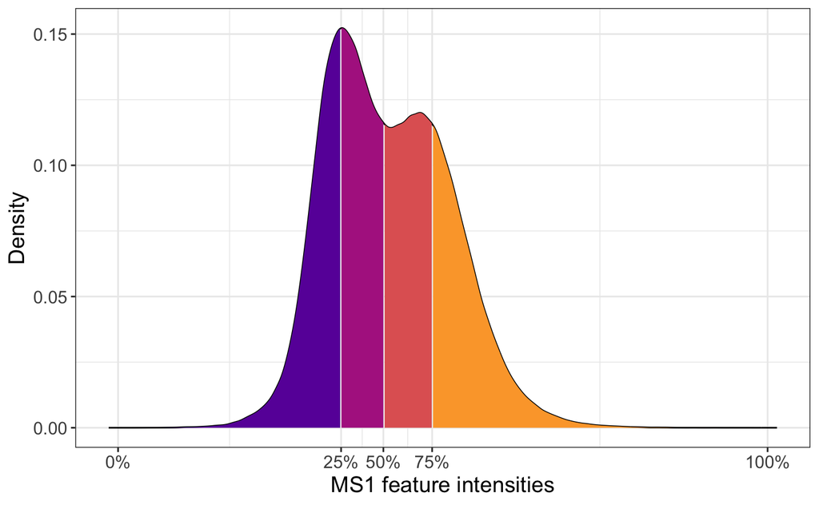

```r
int$quart <- int_4_quartiles
max_to_remove <- int %>% filter(quart == "remove")
max_to_remove <- max_to_remove$intensity %>% max()

dens <- density(log2(int$intensity))
df <- data.frame(x=dens$x, y=dens$y)
probs <- c(0,0.25,0.5,0.75,1)
quantiles <- quantile(log2(int$intensity), prob=probs)
df$quant <- factor(findInterval(df$x,quantiles))


(pep_quart_plot <- ggplot(df, aes(x,y)) + geom_line() +
    geom_ribbon(aes(ymin=0, ymax=y, fill=quant)) +
    scale_x_continuous(breaks=quantiles) +
    #scale_fill_brewer(guide="none") +
    xlab("MS1 feature intensities") +
    ylab("Density") +
    scale_fill_viridis_d(option = "plasma", guide = "none") +
    theme_bw() +
    theme(text=element_text(size=14))
)
```

```r
cond_options_all <- table(dc_metadata$Diagnosis) %>% as.data.frame()
cond_opts_all <- cond_options_all$Var1
cond_count_all <- cond_options_all$Freq * 0.5


is.nan.data.frame <- function(x){
    do.call(cbind, lapply(x, is.nan))}
#df = intensity
#conditions = cond_opts
#min_count = cond_count
## add condition to end of all col names...
filter_valids_quart = function(df, conditions, min_count, int_remove, at_least_one = TRUE) {
    df[is.nan.data.frame(df)] <- 0
    df[is.na(df)] <- 0
    df[df <= int_remove] <- 0
    all_names <- colnames(df)
    cond.names = lapply(conditions, # Group column names by conditions
                        function(x) grep(x, all_names, value = TRUE, perl = TRUE))
    cond.filter = sapply(1:length(cond.names), function(i) {
        df2 = df %>% dplyr::select(cond.names[[i]])   # Extract columns of interest
        df2 = as.matrix(df2)   # Cast as matrix for the following command
        sums = rowSums(df2!=0) # count the number of valid values for each condition
        sums >= min_count[i]   # Calculates whether min_count requirement is met
    })
    if (at_least_one) {
        df$KEEP = apply(cond.filter, 1, any)
    } else {
        df$KEEP = apply(cond.filter, 1, all)
    }
    return(df)  # only keeping rows that meet the criteria!
}



## filter by at least Q50 in each treatment considering ZEROS and anything in low quartile
## trying without any quartile adjustment!
ibd_filt <- filter_valids_quart(intensity %>% dplyr::select(-feat_num),
                               conditions = cond_opts_all,
                               min_count = cond_count_all,
                               int_remove = max_to_remove,
                               at_least_one = T) #213,383
ibd_filt <- intensity[ibd_filt$KEEP == 1,-59] ## 17,035
filt_feat <- rownames(ibd_filt)


norm_feat<- estimateSizeFactorsForMatrix(ibd_filt)
norm_int <- sweep(ibd_filt, 2, norm_feat, "/") ##peptides are normalized

int <- norm_int %>% as.data.frame %>% pivot_longer(names_to = "Name", values_to="intensity", cols=everything()) %>% drop_na()
head(int)
```

| Name | intensity |
| --- | --- |
| HM504_CD_No | 815210395 |
| HM483_CD_Yes | 25964517 |
| HM574_CD_Yes | 35737077 |
| HM569_CD_Yes | 2567031567 |
| HM539_CD_No | 4598272342 |
| HM538_CD_No | 184659278 |

```r
summary(int$intensity)
```

```
     Min.   1st Qu.    Median      Mean   3rd Qu.      Max.
8.212e+03 1.277e+07 5.135e+07 3.163e+08 1.519e+08 2.644e+12
```

```r
int_4_quartiles <- smart_cut(int$intensity,4,"groups", labels = c("remove", "Low", "Med", "High"))
table(int_4_quartiles)
```

```
int_4_quartiles
remove    Low    Med   High
155979 155990 155986 155986
```

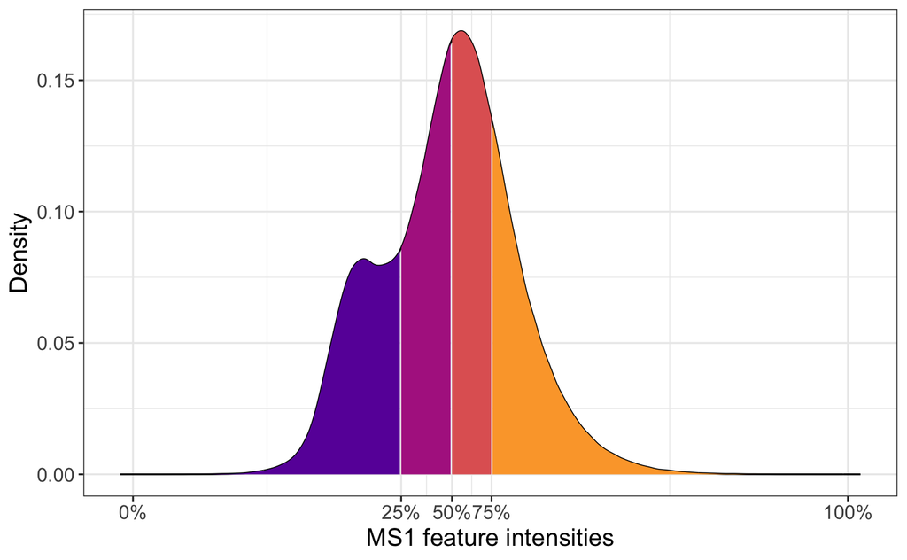

```r
int$quart <- int_4_quartiles
#max_to_remove <- int %>% filter(quart == "remove")
#max_to_remove <- max_to_remove$intensity %>% max()

dens <- density(log2(int$intensity))
df <- data.frame(x=dens$x, y=dens$y)
probs <- c(0,0.25,0.5,0.75,1)
quantiles <- quantile(log2(int$intensity), prob=probs)
df$quant <- factor(findInterval(df$x,quantiles))


(pep_quart_plot <- ggplot(df, aes(x,y)) + geom_line() +
    geom_ribbon(aes(ymin=0, ymax=y, fill=quant)) +
    scale_x_continuous(breaks=quantiles) +
    #scale_fill_brewer(guide="none") +
    xlab("MS1 feature intensities") +
    ylab("Density") +
    scale_fill_viridis_d(option = "plasma", guide = "none") +
    theme_bw() +
    theme(text=element_text(size=14))
)
```

## Missing data imputation

Although we filtered data, we are still left with missing values that will cause challenges with log transformation and fold change calculations. We used a KNN data imputation.

```r
## impute missing values
#intensity_0 <- intensity %>%  mutate_all(~replace(., is.nan(.), 0))

imputed_feat <- impute.knn(norm_int %>% as.matrix(), k = 10, rowmax = 0.5, colmax = 0.95, rng.seed = 362436069)
```

[output not shown]

## Batch effect?

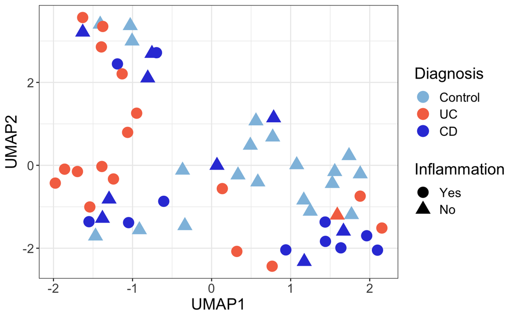

```r
imputed_noZero <- imputed_feat$data
imputed_noZero[imputed_noZero  == 0] <- 0.0001

log_exp <- data.frame(imputed_noZero) %>%
    mutate_all(., funs(log2(.)))
colnames(log_exp) = colnames(imputed_feat$data)
ms1_umap <- umap(log_exp %>% as.matrix %>% t(), n_components=2, random_state=2248)
#ibd_meta <- ibd_meta[match(colnames(log_exp), ibd_meta$NewName),]
coords_umap<-data.frame(ms1_umap$layout, Diagnosis = dc_metadata$Diagnosis,
                   #samplename = colnames(log_exp_DC),
                   Sex = dc_metadata$Gender,
                   #Site = dc_metadata$Location,
                   Inflammation = dc_metadata$Inflammed, Date=dc_metadata$Date)
coords_umap$Diagnosis <- factor(coords_umap$Diagnosis, levels = c("Control", "UC", "CD"))
coords_umap$Inflammation <- factor(coords_umap$Inflammation, levels = c("Yes","No"))
labels <- pretty(coords_umap$Date, 5)
(umap_plot_diagnosis <- ggplot(coords_umap, aes(x = X1, y = X2)) +
        geom_point(size=5, aes(shape = Inflammation, color = Diagnosis)) +
        scale_color_manual(values=c("#8FBFE0", "#F57251",  "#3444DA"))+
        #scale_color_gradient(
  #  low="yellow", high="purple",
  #  breaks = as.integer(labels),
  #  labels = format(labels, "%m/%d/%y")
 # ) +
        scale_x_continuous(name="UMAP1") +
        scale_y_continuous(name="UMAP2") +
        theme_bw() +
        theme(legend.position = "right", text=element_text(size=16)))
```

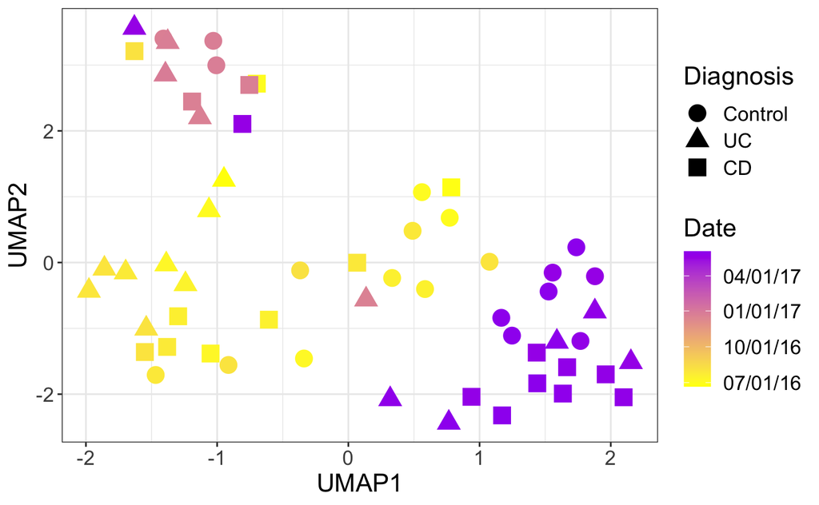

```r
(umap_plot_date <- ggplot(coords_umap, aes(x = X1, y = X2)) +
        geom_point(size=5, aes(shape = Diagnosis, color = Date)) +
        #scale_color_manual(values=c("#3444DA",  "#DF737A", "#8C5999", "#00916E", "#D7C0D0", "#FFBA49")) +
        scale_color_gradient(
    low="yellow", high="purple",
    breaks = as.integer(labels),
    labels = format(labels, "%m/%d/%y")
  ) +
        scale_x_continuous(name="UMAP1") +
        scale_y_continuous(name="UMAP2") +
        theme_bw() +
        theme(legend.position = "right", text=element_text(size=16)))
```

```r
# ggsave(filename = "../../../4.mSystems/2.revisionv2/figs/umap-dc-diagnosis.pdf", umap_plot_diagnosis, width = 8, height = 6, units = "in")
# ggsave(filename = "../../../4.mSystems/2.revisionv2/figs/umap-dc-diagnosis.eps", umap_plot_diagnosis, width = 8, height = 6, units = "in")
# ggsave(filename = "../../../4.mSystems/2.revisionv2/figs/umap-dc-date.pdf", umap_plot_date, width = 8, height = 6, units = "in")
# iggsave(filename = "../../../4.mSystems/2.revisionv2/figs/umap-dc-date.eps", umap_plot_date, width = 8, height = 6, units = "in")
# write.csv(log_exp, here::here("Dataset4-ibd","dc", "dataset4-dc-ms1_log2_normalized.csv"), quote=F, row.names = T)
```

## Log2 intensity transformation and PCA quality check

We then should log transform the intensity values and perform a PCA for a QC check.

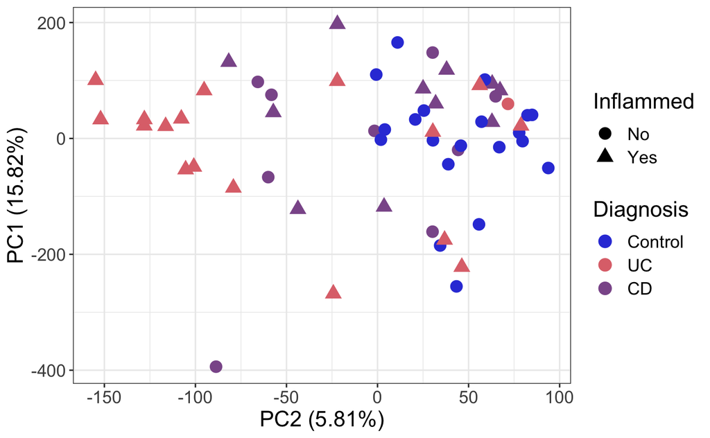

```r
## easy and quick PCA function for manual colour and shape
quick_pca <- function(coords_df, x_PC, y_PC, PoV, shape, fill){
    yaxis <- y_PC
    xaxis <- x_PC
    yperc <- paste0("(", round(PoV[yaxis %>% as.numeric()] ,2), "%)")
    xperc <- paste0("(", round(PoV[xaxis %>% as.numeric()] ,2), "%)")
    yaxislabel <- paste0("PC", yaxis, " ", yperc)
    xaxislabel <- paste0("PC", xaxis, " ", xperc)
    pca_plot <- ggplot(coords_df, aes_string(x = paste0('PC', xaxis), y = paste0('PC', yaxis))) +
        geom_point(size=4, aes_string(shape = shape, color = fill)) +
        scale_color_manual(values=c("#3444DA",  "#DF737A", "#8C5999", "#00916E", "#D7C0D0", "#FFBA49")) +
        scale_x_continuous(name=xaxislabel) +
        scale_y_continuous(name=yaxislabel) +
        theme_bw() +
        theme(legend.position = "right", text=element_text(size=16))
    return(pca_plot)
}

## easy and quick PCA funcDCon for manual colour and shape
quick_pca_date <- function(coords_df, x_PC, y_PC, PoV, shape, fill){
    yaxis <- y_PC
    xaxis <- x_PC
    yperc <- paste0("(", round(PoV[yaxis %>% as.numeric()] ,2), "%)")
    xperc <- paste0("(", round(PoV[xaxis %>% as.numeric()] ,2), "%)")
    yaxislabel <- paste0("PC", yaxis, " ", yperc)
    xaxislabel <- paste0("PC", xaxis, " ", xperc)
    pca_plot <- ggplot(coords_df, aes_string(x = paste0('PC', xaxis), y = paste0('PC', yaxis))) +
        geom_point(size=4, aes_string(shape = shape, color = fill)) +
        #scale_color_manual(values=c("#3444DA",  "#DF737A", "#8C5999", "#00916E", "#D7C0D0", "#FFBA49")) +
  scale_color_gradient(
    low="yellow", high="purple",
    breaks = as.integer(labels),
    labels = format(labels, "%m/%d/%y")
  ) +
      scale_x_continuous(name=xaxislabel) +
        scale_y_continuous(name=yaxislabel) +
        theme_bw() +
        theme(legend.position = "right", text=element_text(size=16))
    return(pca_plot)
}


#log_exp <- data.frame(imputed_feat$data) %>%
#    mutate_all(., funs(log2(1 + .)))
#colnames(log_exp) = colnames(imputed_feat$data)
pca_all<- prcomp(log_exp %>% t(), center=T, scale=F)
sampleVals<-data.frame(pca_all$x)
exprVals<-data.frame(pca_all$rotation)
PoV <- (pca_all$sdev^2/sum(pca_all$sdev^2))*100

coords<-data.frame(sampleVals, Diagnosis = dc_metadata$Diagnosis,
                   samplename = rownames(sampleVals),
                   Sex = dc_metadata$Gender,
                   #Site =  dc_metadata$Location,
                   Inflammed =  dc_metadata$Inflammed, Date= dc_metadata$Date) #,
                   #Age = ibd_meta$Age)
coords$Diagnosis <- factor(coords$Diagnosis, levels = c("Control", "UC", "CD"))
numPCs_all <- 1:length(PoV)

for (i in 1:length(PoV)) {
    percent <- paste0("(", round(PoV[i],2), "%)")
    name <- paste0("PC", i, "per")
    assign(name, percent)
}
(pc12 <- quick_pca(coords_df = coords, x_PC = 2, y_PC = 1, PoV = PoV, shape = "Inflammed", fill = "Diagnosis"))
```

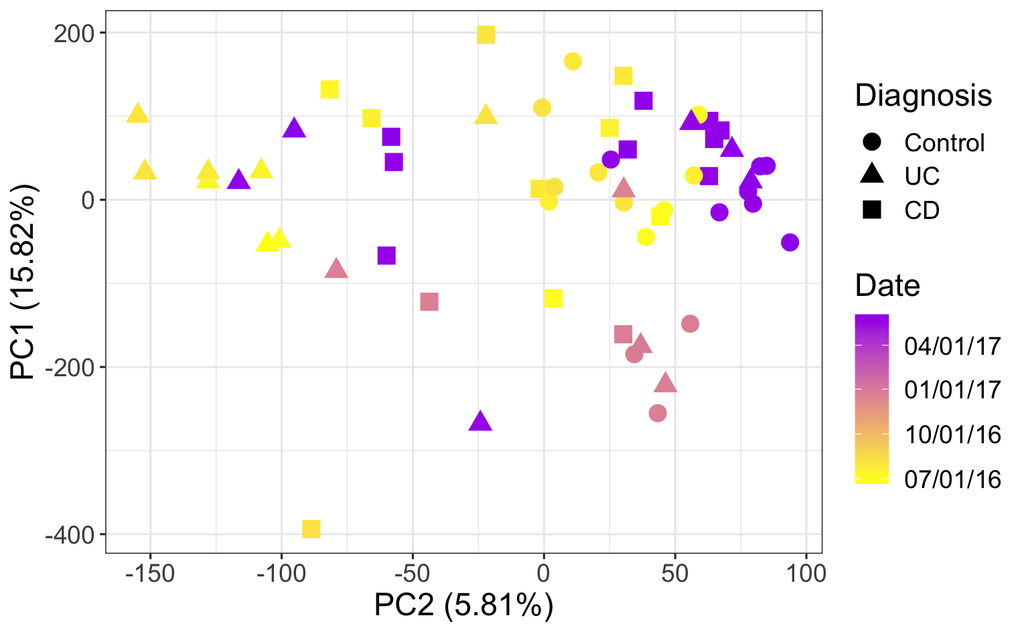

```r
(pc12_all <- quick_pca_date(coords_df = coords, x_PC = 2, y_PC = 1, PoV = PoV, shape = "Diagnosis", fill = "Date"))
```

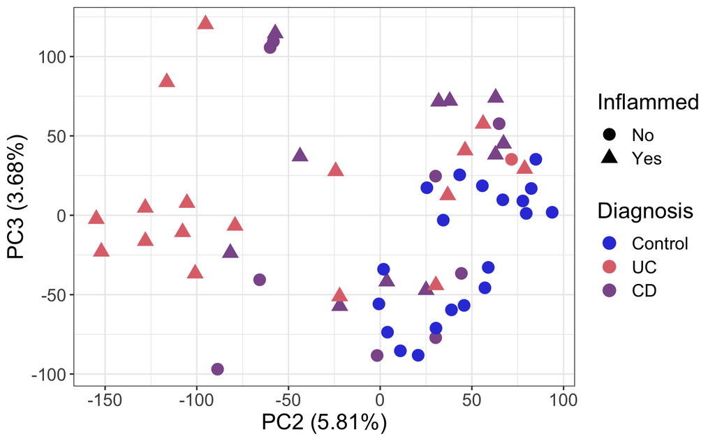

```r
(pc23_all <- quick_pca(coords_df = coords, x_PC = 2, y_PC = 3, PoV = PoV, shape = "Inflammed", fill = "Diagnosis"))
```

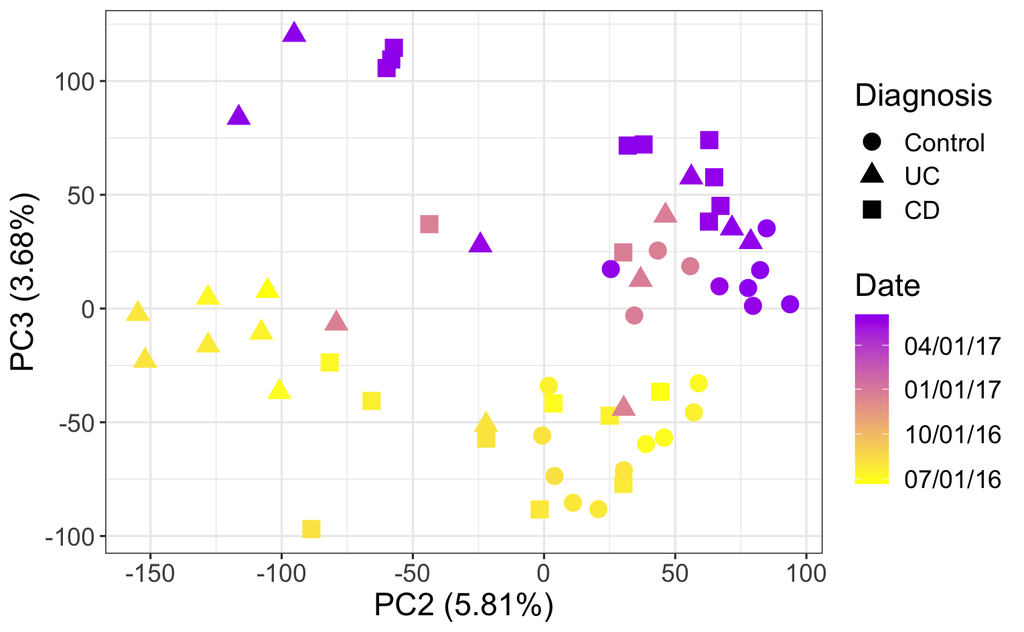

```r
(pc23_all <- quick_pca_date(coords_df = coords, x_PC = 2, y_PC = 3, PoV = PoV, shape = "Diagnosis", fill = "Date"))
```

## Cluster eigenfeature calculation and clustering visualization

```r
kmedoid_labels <- read.csv(here::here("Dataset4-ibd", "dc", "k-med_labels.csv"), header=F) %>% as.vector()

clusterinfopep <- kmedoid_labels %>% data.frame()

max_clust <- kmedoid_labels %>% unique() %>% max()
print(paste("Number of clusters:", max_clust+1))
```

```
[1] "Number of clusters: 10"
```

```r
clusters <- list()

## creating a list that contains intensities of each peptide cluster
for (x in 0:max_clust){
    clustername <- paste("Cluster", x)
    y <- kmedoid_labels[which(kmedoid_labels$V1 == x),,drop=F] %>% rownames()
    intensities <- log_exp[y %>% as.numeric(),] %>% as.data.frame()
    intensities <- intensities %>% mutate(feat_num = y)
    clusters[[clustername]] <- intensities
}

### eigenfactors
### Singular value decomposition for genome-wide expression data processing and modeling
###  https://doi.org/10.1073/pnas.97.18.10101
## https://www.biostars.org/p/299167/
## eigengenes <- svd(X)$v


svd_clusters <- lapply(clusters, function(x) svd(x %>% dplyr::select(-feat_num))$v)
# grabbing the first principal component
svd1_cluster <- lapply(svd_clusters,  "[", , 1)


clustereigenfactors_svd <- bind_cols(svd1_cluster) %>% data.frame()
```

Complete the correlation with groups and inflammation.

```r
## make a factored dataframe of the compounds

dc_metadata <- dc_metadata %>% mutate(diag_inflam = paste0(Diagnosis, "_", Inflammed))

datTraits <- data.frame(diag_inflam =  as.factor(dc_metadata$diag_inflam))
rownames(datTraits) <- dc_metadata$NewName
traits <- model.matrix(~ ., data=datTraits,
                       contrasts.arg = lapply(datTraits, contrasts, contrasts=FALSE))
traits <- traits[,-1] ##removing intercept
#moduleTraitCor_pca <- stats::cor(clustereigenfactors_pca, traits, method = "s")
moduleTraitCor_svd <- stats::cor(clustereigenfactors_svd, traits, method = "s")
#colnames(moduleTraitCor_pca) <- colnames(moduleTraitCor_pca) %>% substr(., 10, nchar(colnames(moduleTraitCor_pca)))
colnames(moduleTraitCor_svd) <- colnames(moduleTraitCor_svd) %>% substr(., 12, nchar(colnames(moduleTraitCor_svd)))
```

Now, let’s look at *SVD-derived* eigenfeatures (this is the more common way of calculating an eigenfeature).

```r
module_clust_svd <- hclust(as.dist(1-cor(t(moduleTraitCor_svd), method="pearson")), method="average")
drug_clust_svd <- hclust(as.dist(1-cor(moduleTraitCor_svd, method="pearson")), method="average")
drug_clust_boot_svd <- pvclust(moduleTraitCor_svd, method.hclust="average",
                           method.dist="correlation", nboot=1000,
                           iseed=2248)
```

```
Bootstrap (r = 0.5)... Done.
Bootstrap (r = 0.6)... Done.
Bootstrap (r = 0.7)... Done.
Bootstrap (r = 0.8)... Done.
Bootstrap (r = 0.9)... Done.
Bootstrap (r = 1.0)... Done.
Bootstrap (r = 1.1)... Done.
Bootstrap (r = 1.2)... Done.
Bootstrap (r = 1.3)... Done.
Bootstrap (r = 1.4)... Done.
```

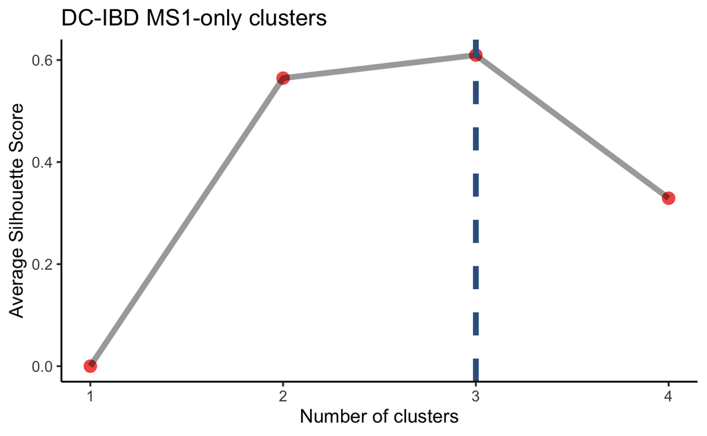

```r
quick_sil <- function(hclust_out, distance, max_k){
  silhouette_score <- function(i){
    k=cutree(hclust_out,i)
    ss <- silhouette(k, 1-cor(distance, method="pearson"))
    mean(ss[, 3])
    }
  clustnum <- 2:max_k
  avg_sil <- sapply(clustnum, silhouette_score)
  avg_sil <- data.frame(num = clustnum, sil_score = avg_sil)
  avg_sil <- rbind(c(1,0), avg_sil)
  return(avg_sil)
}
#
ms1_svd_sil <- quick_sil(hclust_out=drug_clust_svd, distance = 1-cor(moduleTraitCor_svd, method="pearson"), max_k = 4)
(ms1_sil <- ggplot(ms1_svd_sil, aes(x=num, y = sil_score)) +
  geom_point(size=4, colour="#F25C54", alpha=1) +
    geom_line(size=2, alpha=0.4) +
    geom_vline(xintercept=3, size = 2, linetype="dashed", color = "#38618C") +
    xlab("Number of clusters") +
    ylab("Average Silhouette Score") +
    scale_x_continuous(breaks = 1:30) +
    theme_classic(base_size=14) +
    ggtitle("DC-IBD MS1-only clusters")
)
```

```r
## Visualize the bootstrap clusters
clust_boot_svd <- as.dendrogram(drug_clust_boot_svd)
#pdf(here::here("figs", "ms1_bootstrap_dend.pdf"), width=9, height =4)
drug_clust_boot_svd %>% as.dendrogram() %>% plot(main = "MS1")
drug_clust_boot_svd %>% text
```

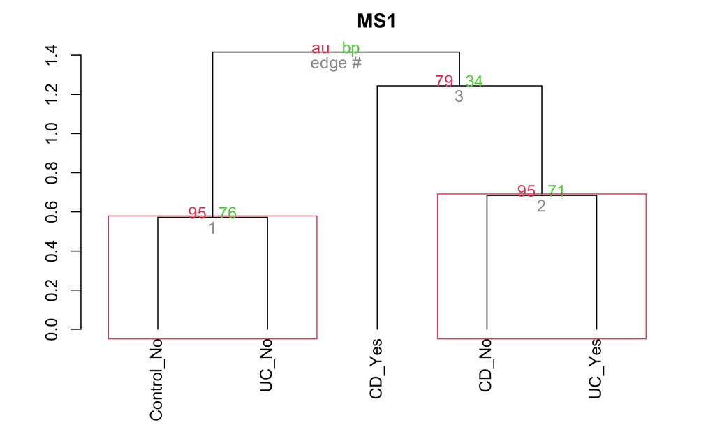

```r
drug_clust_boot_svd %>% pvrect(alpha=0.9, pv="au")
```

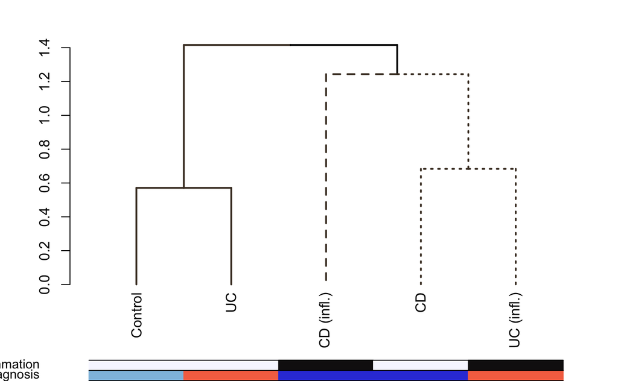

```r
#dev.off()

## colours for dendrogram branches
clust_cols_ms1_svd <- c("#48392A", "#48392A")

dc_ibd_dend <- color_branches(as.dendrogram(drug_clust_svd), k = 3, col = clust_cols_ms1_svd) %>%
    dendextend::set("branches_lwd", 2)

k_3 <- cutree(dc_ibd_dend, k = 3, order_clusters_as_data = FALSE)
dc_ibd_dend <- branches_attr_by_clusters(
  dc_ibd_dend,
  clusters = k_3,
  values = c(1,2,3),
  attr =  "lty"
)
## metadata for clustr heatmap
#"#1446A0",  "#DB3069", "#FFBA08
cor_meta_svd <- data.frame(Sample = labels(dc_ibd_dend)) %>%
    mutate(overall = case_when(str_detect(Sample, 'CD_Yes') ~ '#1446A0',
                                str_detect(Sample, 'UC_Yes') ~ '#DB3069',
                                str_detect(Sample, 'UC_No') ~ '#FFBA08',
                                str_detect(Sample, "CD_No") ~ '#5AAA95',
                               str_detect(Sample, "Control_No") ~ "grey"),
    Diagnosis = case_when(str_detect(Sample, 'UC') ~ '#F57251',
                          str_detect(Sample, 'CD') ~ '#3444DA',
                          str_detect(Sample, 'Control') ~ '#8FBFE0'),
    Inflammation = case_when(str_detect(Sample, 'Yes') ~ '#131112',
                          str_detect(Sample, 'No') ~ '#F7F7FF'))


dc_ibd_dend <- dc_ibd_dend %>% set_labels(., labels = c("Control", "UC", "CD (infl.)", "CD", "UC (infl.)"))

#pdf(here::here("Dataset4-ibd", "dc", "ibd-dc-dend.pdf"))
dc_ibd_dend %>% plot()
colored_bars(colors = cor_meta_svd %>% dplyr::select(-Sample, -overall), dend = dc_ibd_dend, sort_by_labels_order = FALSE)
```

```r
#dev.off()
```

# Biomarker discovery through machine learning

The above demonstrates the **potential** to identify biomarkers using this approach. Let’s use a more iterative approach by using machine learning. It is likely that we will need to use a combination of many biomarkers (a panel).

Let’s start with UC_A biomarker selection.

It’s important to consider we have way more predictors than samples (p >> n). We will need a solution that considers this. Check out these manuscript that may help:

- -Omics biomarker identification pipeline for translational medicine](https://doi.org/10.1186/s12967-019-1912-5))

- Statistical predictions with glmnet](https://doi.org/10.1186/s13148-019-0730-1))

Elastic net (`glmnet`) and lasso can be used for feature selection… (and therefore biomarker selection.)

Let’s show how we can use Lasso to identify for features that can identify CD without inflammation.

# Feature selection function

```r
### Currently this function is specific to IBD data
## Can definitely be changed to be appropriate for any other data.
auto_feature_selection <- function(log_exp, kmed_labels, cond, cluster_cor, metadata= dc_metadata, randomnumber=1234){

 # kmed_labels=kmedoid_labels
#  cond= "CD_Yes"
#  cluster_cor = moduleTraitCor_svd
#  randomnumber = 1234



  clusterinfofeat <- kmed_labels %>% data.frame()
  cor_info <- data.frame(cluster_cor)

  ## Highest absolute correlation to condition of choice
  clust_pred <- which(clusterinfofeat$V1 == which.max(abs(cor_info[,cond]))-1)
  cluster_chosen <- which.max(abs(cor_info[,cond]))-1

  ## Organizing data
  feat_pred <- filt_feat[clust_pred] %>% as.numeric()
  log_int <- log_exp[clust_pred,] %>% ## the rownames with the clusters
    mutate(feat_num = feat_pred) ## the actual feature names because youll need them to extract the info
  ## Updating the metadata to include a binary variable of choice
  ibd_meta_imp <- metadata %>% dplyr::select(NewName, diag_inflam) %>%
  mutate(diagnosis = case_when(diag_inflam == cond ~ 1,
                          diag_inflam != cond ~ 0))

  ## Transposing the cluster feature for glm
   clustfeat <- log_int %>% t() %>% as.data.frame() %>%
    rownames_to_column("NewName") %>%
    left_join(ibd_meta_imp, . , by="NewName") %>% dplyr::select(-NewName, -diag_inflam)
  # outcome for glm
  clustfeat_outcome <- clustfeat %>% dplyr::select(diagnosis) %>% as.matrix(.)
  # getting features ready for glm once again
  clustfeat <- data.matrix(clustfeat[,-1])
  colnames(clustfeat) <- 1:ncol(clustfeat) ## now they are NO LONGER the feature numbers.

  ## LASSO, leave-one-out cross validation
  outcome <- clustfeat_outcome[,1]
  set.seed(randomnumber)
  ## estimating the ideal lambda for final model
  clustfeatlasso <- cv.glmnet(clustfeat, outcome, family = "binomial", nfold = ncol(log_exp) , type.measure = "auc", paralle = F, alpha = 1, keep=T)

  model_final <- glmnet(clustfeat, outcome, family = "binomial", lambda = clustfeatlasso$lambda.1se, alpha = 1) #lambda.1se is the most regularized model

 #broom::tidy(model_final)

  # calculating the predicton accuracy using L-O-O yet again
  k <- dim(clustfeat)[1]
  predictions <- c()
  for (i in 1:k) {
    model <- glmnet(clustfeat[-i,],  outcome[-i], family="binomial", lambda = clustfeatlasso$lambda.1se, alpha = 1)
    predictions <- c(predictions, predict(model, newx=clustfeat[i,]))
  }
  # ROC curve for AUC calculation and visualization
  roc_curve <- roc(outcome, predictions)
  auc <- round(auc(outcome, predictions),4)
  print(auc)
  ## grabbing the features with non-zero coefficients
  `%ni%` <- Negate(`%in%`)
  c<-coef(model_final) #,  s='lambda.1se') #, x=clustfeat, y=clustfeat_outcome$UCinfl, s='lambda.min',exact=TRUE)
  inds<-which(c!=0)
  variables<-rownames(c)[inds]
  variables<-variables[variables %ni% '(Intercept)'] %>% as.numeric()


  selected <- log_int[variables,]
  selected <- selected %>%  pivot_longer(!feat_num, names_to="Sample", values_to="log2_intensity") %>%
    mutate(Coefficient = rep("Non-zero", nrow(.)))
  notselected <- log_int[-variables,]
  notselected <- notselected %>%  pivot_longer(!feat_num, names_to="Sample", values_to="log2_intensity") %>%
    mutate(Coefficient = rep("Zero", nrow(.)))

  features <- rbind(selected, notselected)
  features <- merge(features, ibd_meta_imp, by.x="Sample", by.y="NewName") %>%
    mutate(diag_inflam = case_when(diag_inflam=="Control_No" ~ "Control",
                                   diag_inflam=="CD_No" ~ "CD",
                                   diag_inflam=="CD_Yes" ~ "CD (inflam.)",
                                   diag_inflam=="UC_No" ~ "UC",
                                   diag_inflam=="UC_Yes" ~ "UC (inflam.)"))


  features$diag_inflam <- factor(features$diag_inflam,
                                         levels = c("Control", "CD", "CD (inflam.)", "UC", "UC (inflam.)"))

  # summarized feature values
  meanvals <- features %>% group_by(feat_num, diag_inflam, Coefficient) %>%
    dplyr::summarize(averageval = mean(log2_intensity, na.rm=TRUE))
  meanvals$Coefficient <- factor(meanvals$Coefficient, levels = c("Non-zero", "Zero"))

  #ggplot
  (group_plot<- ggplot(meanvals, aes(x=diag_inflam, y=averageval,colour=Coefficient))+ #, fill=diag_inflam))
       geom_point(alpha=0.5, position=position_jitterdodge()) +
      geom_boxplot(outlier.shape=NA, alpha=0.7) +

    scale_colour_manual(name = "Coefficients", values=c("Red", "grey31")) +
  ylab("Mean log2 intensity by feature") +
  xlab("Diagnosis"))

  selected_featnum <- selected$feat_num %>% unique()

  feat_rt_mz <- intensity_withcf[selected_featnum,] %>% dplyr::select(feature_num, RT, MZ)

  ## all the variables to return...
  toreturn <- list(final_model = model_final,
                  roc = roc_curve,
                  auc = auc,
                  cluster = cluster_chosen,
                  cluster_feat = features,
                  summarized_feat = meanvals,
                  feat_plot = group_plot,
                  feat_rt_mz = feat_rt_mz)
  return(toreturn)
    }

CD_N_res <- auto_feature_selection(log_exp=log_exp, kmed_labels = kmedoid_labels, cond="CD_No",
                       cluster_cor = moduleTraitCor_svd)
```

```
[1] 1
```

```r
broom::tidy(CD_N_res$final_model)
```

| term | step | estimate | lambda | dev.ratio |
| --- | --- | --- | --- | --- |
| (Intercept) | 1 | -1.694596 | 0.1707999 | -1.414863e-15 |

```r
### AUC = 0.809
CD_Y_res <- auto_feature_selection(log_exp=log_exp, kmed_labels = kmedoid_labels, cond="CD_Yes",
                       cluster_cor = moduleTraitCor_svd)
```

```
[1] 0.8085
```

```r
broom::tidy(CD_Y_res$final_model)
```

| term | step | estimate | lambda | dev.ratio |
| --- | --- | --- | --- | --- |
| (Intercept) | 1 | 1.497401166 | 0.1757362 | 0.1556563 |
| 384 | 1 | -0.003443868 | 0.1757362 | 0.1556563 |
| 976 | 1 | -0.098533167 | 0.1757362 | 0.1556563 |
| 1124 | 1 | -0.006764332 | 0.1757362 | 0.1556563 |

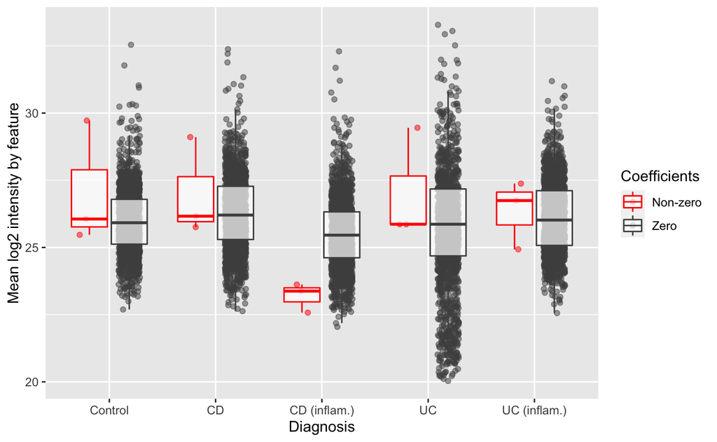

```r
CD_Y_res$feat_plot
```

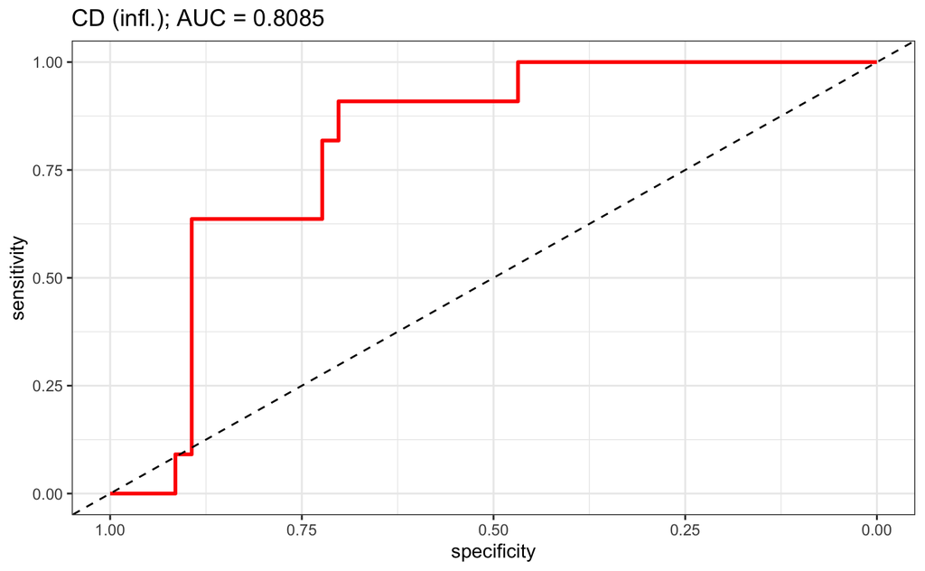

```r
(CD_Y_roc <- ggroc(CD_Y_res$roc, colour = 'red', size = 1) +
  ggtitle(paste0('CD (infl.); AUC = ', CD_Y_res$auc)) +
  geom_abline(intercept=1, slope=1, linetype="dashed") +
  theme_bw())
```

```r
#ggsave(here::here("Dataset4-ibd", "dc", "feat_selection", "CD_Y_feat.pdf"), CD_Y_res$feat_plot)
#ggsave(here::here("Dataset4-ibd", "dc", "feat_selection", "CD_Y_roc.pdf"), CD_Y_roc)
#write.csv(CD_Y_res$feat_rt_mz, here::here("Dataset4-ibd", "dc", "feat_selection", "CD_Y_mz-rt.csv"), row.names=F, quote =F)

#UC_N_res <- auto_feature_selection(log_exp=log_exp, kmed_labels = kmedoid_labels, cond="UC_No",
#                       cluster_cor = moduleTraitCor_svd)
#broom::tidy(UC_N_res$final_model)
#UC_N_res$roc

UC_Y_res <- auto_feature_selection(log_exp=log_exp, kmed_labels = kmedoid_labels, cond="UC_Yes",
                       cluster_cor = moduleTraitCor_svd)
```

```
[1] 0.7145
```

```r
broom::tidy(UC_Y_res$final_model)
```

| term | step | estimate | lambda | dev.ratio |
| --- | --- | --- | --- | --- |
| (Intercept) | 1 | -7.39869544 | 0.1773254 | 0.22738 |
| 71 | 1 | 0.03461456 | 0.1773254 | 0.22738 |
| 84 | 1 | 0.07503901 | 0.1773254 | 0.22738 |
| 120 | 1 | 0.03201383 | 0.1773254 | 0.22738 |
| 387 | 1 | 0.05966717 | 0.1773254 | 0.22738 |
| 769 | 1 | 0.01491371 | 0.1773254 | 0.22738 |
| 1080 | 1 | 0.02049835 | 0.1773254 | 0.22738 |

```r
UC_Y_res$roc
```

```
Call:
roc.default(response = outcome, predictor = predictions)

Data: predictions in 41 controls (outcome 0) < 17 cases (outcome 1).
Area under the curve: 0.7145
```

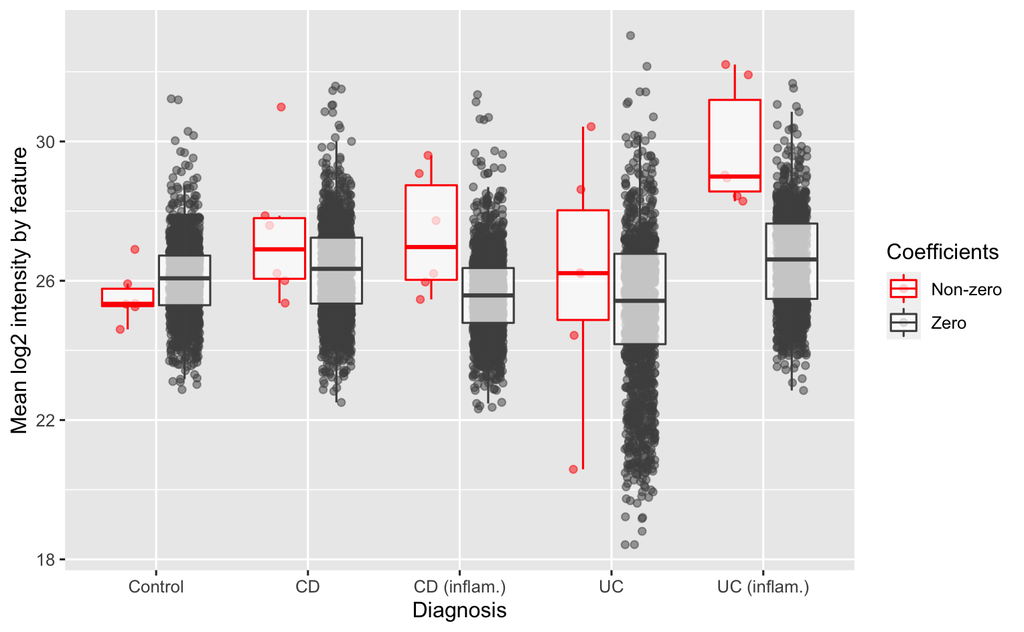

```r
UC_Y_res$feat_plot
```

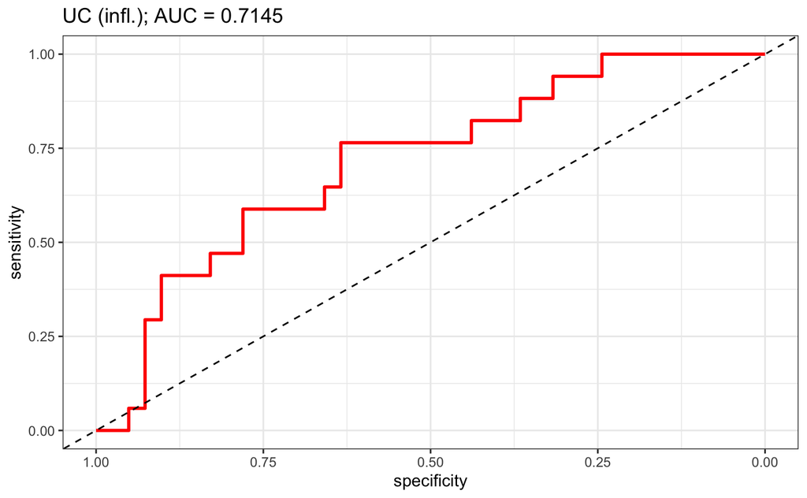

```r
(UC_Y_roc <- ggroc(UC_Y_res$roc, colour = 'red', size = 1) +
  ggtitle(paste0('UC (infl.); AUC = ', UC_Y_res$auc)) +
  geom_abline(intercept=1, slope=1, linetype="dashed") +
  theme_bw())
```

```r
#ggsave(here::here("Dataset4-ibd", "dc", "feat_selection", "UC_Y_feat.pdf"), UC_Y_res$feat_plot)
#ggsave(here::here("Dataset4-ibd", "dc", "feat_selection", "UC_Y_roc.pdf"), UC_Y_roc)
#write.csv(UC_Y_res$feat_rt_mz, here::here("Dataset4-ibd", "dc", "feat_selection", "UC_Y_mz-rt.csv"), row.names=F, quote =F)

Control_res <- auto_feature_selection(log_exp=log_exp, kmed_labels = kmedoid_labels, cond="Control_No",
                       cluster_cor = moduleTraitCor_svd)
```

```
[1] 0.9158
```

```r
broom::tidy(Control_res$final_model)
```

| term | step | estimate | lambda | dev.ratio |
| --- | --- | --- | --- | --- |
| (Intercept) | 1 | -4.38617913 | 0.1347181 | 0.4396338 |
| 43 | 1 | -0.07166007 | 0.1347181 | 0.4396338 |
| 101 | 1 | -0.07791097 | 0.1347181 | 0.4396338 |
| 272 | 1 | -0.06351789 | 0.1347181 | 0.4396338 |
| 314 | 1 | 0.06890784 | 0.1347181 | 0.4396338 |
| 875 | 1 | 0.02179925 | 0.1347181 | 0.4396338 |
| 1472 | 1 | 0.05065564 | 0.1347181 | 0.4396338 |
| 1488 | 1 | 0.18861930 | 0.1347181 | 0.4396338 |
| 1556 | 1 | 0.03064663 | 0.1347181 | 0.4396338 |

```r
Control_res$roc
```

```
Call:
roc.default(response = outcome, predictor = predictions)

Data: predictions in 38 controls (outcome 0) < 20 cases (outcome 1).
Area under the curve: 0.9158
```

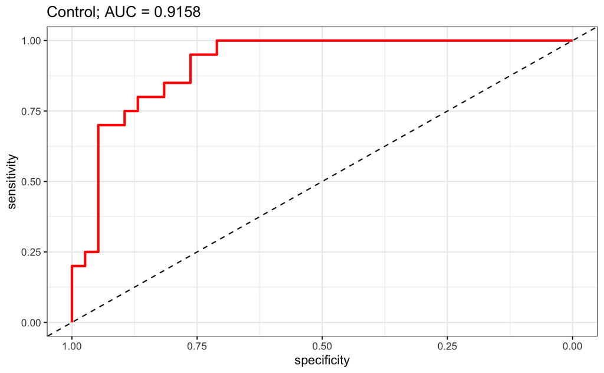

```r
(Control_roc <- ggroc(Control_res$roc, colour = 'red', size = 1) +
  ggtitle(paste0('Control; AUC = ', Control_res$auc)) +
  geom_abline(intercept=1, slope=1, linetype="dashed") +
  theme_bw())
```

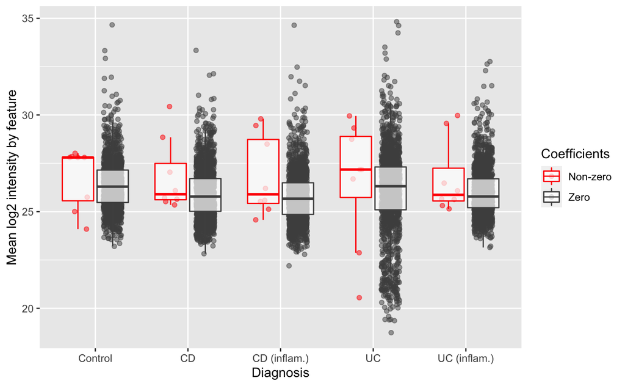

```r
Control_res$feat_plot
```

```r
ctrl_feat <- Control_res$feat_rt_mz
#write.csv(Control_res$feat_rt_mz, here::here("Dataset4-ibd", "dc", "feat_selection", "Ctrl_mz-rt.csv"), row.names=F, quote =F)
#ggsave(here::here("Dataset4-ibd", "dc", "feat_selection", "Ctrl_feat.pdf"), Control_res$feat_plot)
#ggsave(here::here("Dataset4-ibd", "dc", "feat_selection", "Ctrl_roc.pdf"), Control_roc)
```